# Models

```r
library(tidyverse)
library(modelr)
library(broom)

wages <- heights %>% filter(income > 0)
```

## Your Turn 1

Fit the model on the slide and then examine the output. What does it look like?

```r
## Your Turn 1
mod_e <- wages %>%
  lm(log(income) ~ education, data = .)
```

## Your Turn 2

Use a pipe to model `log(income)` against `height`. Then use broom and dplyr functions to extract:

1. The **coefficient estimates** and their related statistics
2. The **adj.r.squared** and **p.value** for the overall model

```r
## Your Turn 2
mod_h <- wages %>% lm(log(income) ~ height, data = .)
mod_h %>%
  tidy()
```

| term | estimate | std.error | statistic | p.value |
| --- | --- | --- | --- | --- |
| (Intercept) | 6.98342583 | 0.237484827 | 29.40578 | 4.129821e-176 |
| height | 0.05197888 | 0.003521666 | 14.75974 | 2.436945e-48 |

```r
mod_h %>%
  glance() %>%
  select(adj.r.squared, p.value)
```

| adj.r.squared | p.value |
| --- | --- |
| 0.03955779 | 2.436945e-48 |

## Your Turn 3

Model `log(income)` against `education` *and* `height`. Do the coefficients change?

```r
## Your Turn 3
mod_eh <- wages %>%
  lm(log(income) ~ education + height, data = .)

mod_eh %>%
  tidy()
```

| term | estimate | std.error | statistic | p.value |
| --- | --- | --- | --- | --- |
| (Intercept) | 5.34837618 | 0.231320415 | 23.12107 | 1.002503e-112 |
| education | 0.13871285 | 0.005205245 | 26.64867 | 7.120134e-147 |
| height | 0.04830864 | 0.003309870 | 14.59533 | 2.504935e-47 |

## Your Turn 4

Model `log(income)` against `education` and `height` and `sex`. Can you interpret the coefficients?

```r
## Your Turn 4
mod_ehs <- wages %>%
  lm(log(income) ~ education + height + sex, data = .)

mod_ehs %>%
  tidy()
```

| term | estimate | std.error | statistic | p.value |
| --- | --- | --- | --- | --- |
| (Intercept) | 8.250422260 | 0.334703051 | 24.649976 | 4.681336e-127 |
| education | 0.147983063 | 0.005196676 | 28.476486 | 5.164290e-166 |
| height | 0.006726614 | 0.004792698 | 1.403513 | 1.605229e-01 |
| sexfemale | -0.461747002 | 0.038941592 | -11.857425 | 5.022841e-32 |

## Your Turn 5

Use a broom function and ggplot2 to make a line graph of `height` vs `.fitted` for our heights model, `mod_h`.

*Bonus: Overlay the plot on the original data points.*

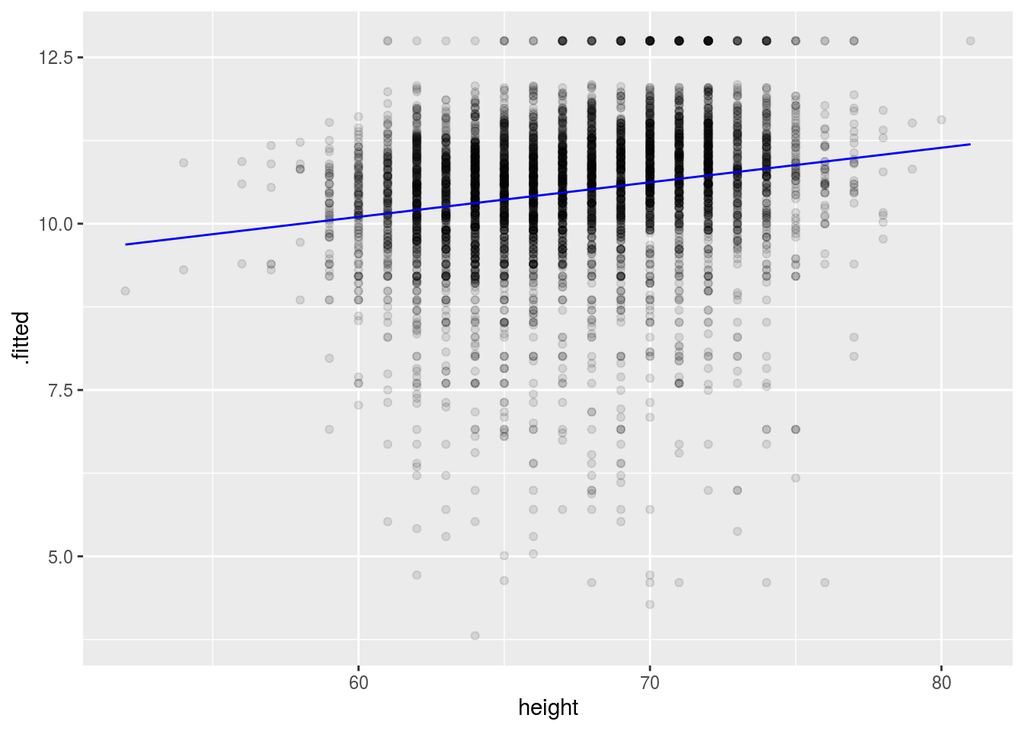

```r
## Your Turn 5
mod_h %>%
  augment(data = wages) %>%
  ggplot(mapping = aes(x = height, y = .fitted)) +
    geom_point(mapping = aes(y = log(income)), alpha = 0.1) +
    geom_line(color = "blue")
```

## Your Turn 6

Repeat the process to make a line graph of `height` vs `.fitted` colored by `sex` for model mod_ehs. Are the results interpretable? Add `+ facet_wrap(~education)` to the end of your code. What happens?

```
## geom_path: Each group consists of only one observation. Do you need to adjust
## the group aesthetic?
## geom_path: Each group consists of only one observation. Do you need to adjust
## the group aesthetic?
```

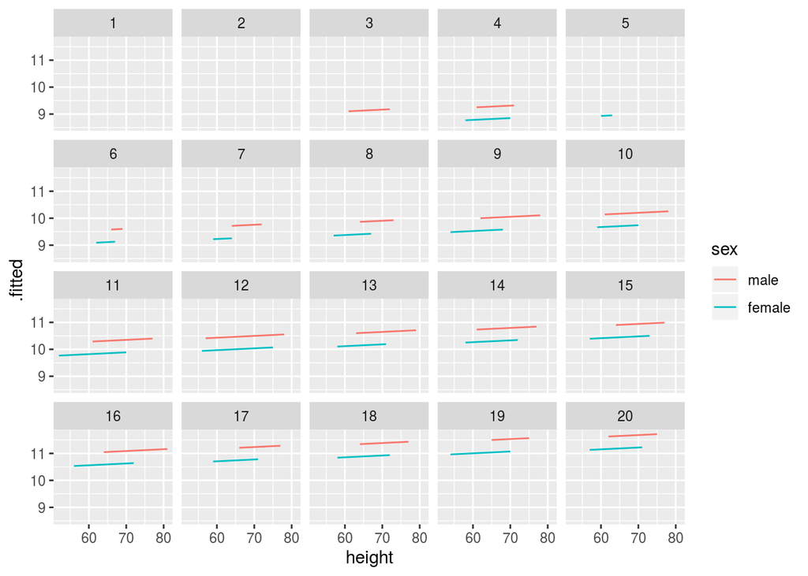

```r
## Your Turn 6
mod_ehs %>%
  augment(data = wages) %>%
  ggplot(mapping = aes(x = height, y = .fitted, color = sex)) +
    geom_line() +
    facet_wrap(~ education)
```

## Your Turn 7

Use one of `spread_predictions()` or `gather_predictions()` to make a line graph of `height` vs `pred` colored by `model` for each of mod_h, mod_eh, and mod_ehs. Are the results interpretable?

Add `+ facet_grid(sex ~ education)` to the end of your code. What happens?

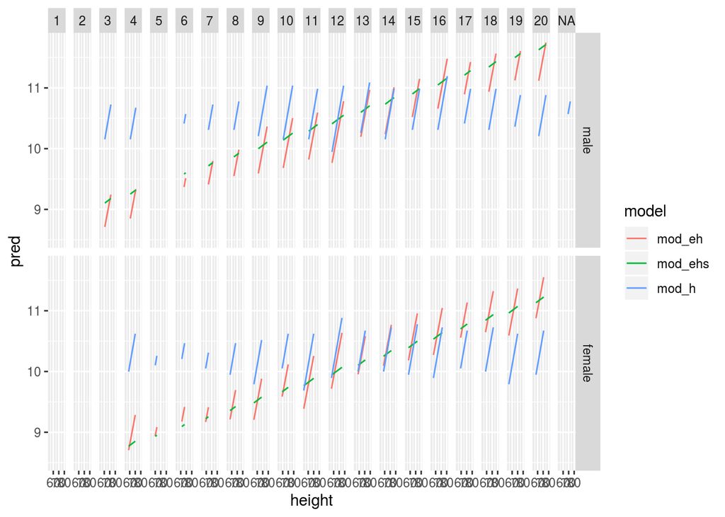

```r
## Your Turn 7
mod_h <- wages %>% lm(log(income) ~ height, data = .)
mod_eh <- wages %>% lm(log(income) ~ education + height, data = .)
mod_ehs <- wages %>% lm(log(income) ~ education + height + sex, data = .)

wages %>%
  gather_predictions(mod_h, mod_eh, mod_ehs) %>%
  ggplot(mapping = aes(x = height, y = pred, color = model)) +
    geom_line() +
    facet_grid(sex ~ education)
```

## Appendix 1 - all code used in this training

```r
library(tidyverse)
library(modelr)
library(broom)

wages <- heights %>% filter(income > 0)
## Your Turn 1
mod_e <- wages %>%
  lm(log(income) ~ education, data = .)
## Your Turn 2
mod_h <- wages %>% lm(log(income) ~ height, data = .)
mod_h %>%
  tidy()

mod_h %>%
  glance() %>%
  select(adj.r.squared, p.value)

## Your Turn 3
mod_eh <- wages %>%
  lm(log(income) ~ education + height, data = .)

mod_eh %>%
  tidy()

## Your Turn 4
mod_ehs <- wages %>%
  lm(log(income) ~ education + height + sex, data = .)

mod_ehs %>%
  tidy()

## Your Turn 5
mod_h %>%
  augment(data = wages) %>%
  ggplot(mapping = aes(x = height, y = .fitted)) +
    geom_point(mapping = aes(y = log(income)), alpha = 0.1) +
    geom_line(color = "blue")

## Your Turn 6
mod_ehs %>%
  augment(data = wages) %>%
  ggplot(mapping = aes(x = height, y = .fitted, color = sex)) +
    geom_line() +
    facet_wrap(~ education)

## Your Turn 7
mod_h <- wages %>% lm(log(income) ~ height, data = .)
mod_eh <- wages %>% lm(log(income) ~ education + height, data = .)
mod_ehs <- wages %>% lm(log(income) ~ education + height + sex, data = .)

wages %>%
  gather_predictions(mod_h, mod_eh, mod_ehs) %>%
  ggplot(mapping = aes(x = height, y = pred, color = model)) +
    geom_line() +
    facet_grid(sex ~ education)
```